# CSGO's Economy

[figure not shown]

### INTRODUCTION

Author: Andreas Verdelis (Solo)

Counter-Strike: Global Offensive is one of the most popular competitive shooters in modern day gaming. It is one of the original and largest 'Esports' with major tournaments sometimes paying out more than $1 Million to the winning team.

The format of a match is relatively simple. There are two teams with 5 players on each team. To win the match a team must win 16 rounds. Each time starts on a side (Terrorist or CounterTerrorist). The terrorists can win the round by either planting the bomb or by killing all of the CounterTerrorists. The CounterTerrorists can win the round by killing all the Terrorists before the bomb is planted, defusing the bomb once it is planted, or by having the timer on the round expire before the Terrorists plant the bomb. At halftime (15 rounds) the teams switch sides so that both teams get to either plant or defend the bombsites. The match ties if both teams win exactly 15 rounds. In professional play the match goes into overtime in this case.

Here I link a great article covering the in-game and economic basics of CSGO: [The Basics](https://dotesports.com/counter-strike/news/beginners-in-depth-introduction-to-csgo-and-its-economy-system-7770)

The game has a very unique economy that we will be focused on for the remainder of this tutorial. On rounds 1 and 16, the first round of each half, each team starts with a set amount of money (800 per player for a total of 4000). Players get money for winning the round, killing enemy players, losing the round (a lot less), and planting the bomb. This money carries into the next round and can be used to purchase better weapons, armor (adds to player hp), and utilities (grenades, smoke grenades, ect.). Being 'rich' gives a player a huge advantage in-game. Utilities like smoke and flashbang grenades can make killing clevely hidden enemies and planting the bomb easier, and molotov grenades can make protecting the bombsite easier. More expensive guns like the AK47 and AWP can kill enemies in one-hit instead of having to fire an entire magazine accurately, and when playing against players so poor they cannot buy armor, an AK47 is almost unstoppable. The developers of the game realize the impact on having money, and to avoid having some earlier round wins snowball one team into a huge economic lead, individual players cannot hold more than $16,000. But even 16,000 per player means a team has 80,000 total, a huge lead, so the poorer enemy team sometimes has to spend all of their money in one round after saving for a few rounds to try and turn the economic tides of the game so they can start to win rounds. The competitive community has designated the types of round economies with names, which I will define below.

[figure not shown]

- Pistol Round : Either the 1rst or 16th round. Both teams are equipped with the starter pistols and have the same small set amount of money
- Economy Round (ECO) : One team posseses a huge economic lead and the other is forced to save entirely, buying cheap weapons and couple utilities if anything. The poorer team is looking to save money for next round to buy better gear and look for a round win to start making money.
- Semi-Eco : Similar to the economy round above but the gap in money is not as large, so the poorer team can buy a little more gear but still not an equal playing field.
- Force Buy : In a force buy round the gap in money is large like in Economy, but the poorer team knows that giving up another round to save money is just not an option (like if the enemy only needs one more round to win) and is forced to purcahse as much as they can and deplete all their savings.
- Normal : A normal round in which both teams have a good savings and can buy all the gear they need.

In this project I will aim to look at the effect different round economies have on winning/losing, how important it is to win a round given the economic climate, and how different economies force players into different play on any given map. This is important because with millions on the line in large tournaments and teams hiring large coaching staffs, CSGO pro teams are looking for any information that can help them train and strategize. And with all of the money coming into ESports these teams will turn to data science to see if it can help.

### IMPORTS

```python
#import pandas numpy for data
#seaborn and mpl for platting
#warnings to ignore warnings
import pandas as pd
import numpy as np
import seaborn as sns
import matplotlib.pyplot as plt
import warnings
#import imread for heatmaps with csgo map overlay
from scipy.misc import imread
import matplotlib.patches as mpatches
from matplotlib.collections import PatchCollection
import matplotlib.colors as colors

warnings.filterwarnings('ignore')
%matplotlib inline
```

### DATA IMPORT AND CLEANING

Here I import the data im using, sourced from around 9300 ESEA games (ESEA is a competitive CSGO server hub). This data is split into two parts, the damage data, which logs things like player location, enemy location, type of gun, damage, and playerID among others with one row per bullet fired per match. And the other part is the meta data which is one row per round per match for those same 9300 ESEA games and has things like the map the round took place on, the winner of the round, and the equipment value (not savings) of each team that round. It most importantly also has the economic round types I explained above logged (PISTOL, ECO, SEMI-ECO, NORMAL, FORCE).

This data was source from Kaggle [here](https://www.kaggle.com/skihikingkevin/csgo-matchmaking-damage/home)

```python
#Read the downloaded csvs of csgo data in as dataframes
df = pd.read_csv('esea_master_dmg_demos.part1.csv')
df_meta = pd.read_csv('esea_meta_demos.part1.csv')
df
```

|  | file | round | tick | seconds | att_team | vic_team | att_side | vic_side | hp_dmg | arm_dmg | ... | wp | wp_type | att_id | att_rank | vic_id | vic_rank | att_pos_x | att_pos_y | vic_pos_x | vic_pos_y |
| --- | --- | --- | --- | --- | --- | --- | --- | --- | --- | --- | --- | --- | --- | --- | --- | --- | --- | --- | --- | --- | --- |
| 0 | esea_match_13770997.dem | 1 | 14372 | 111.8476 | World | Animal Style | None | CounterTerrorist | 1 | 0 | ... | Unknown | Unkown | 0 | 0 | 76561198055054795 | 0 | 0.00000 | 0.00000 | 0.00000 | 0.000000 |
| 1 | esea_match_13770997.dem | 1 | 15972 | 124.3761 | Animal Style | Hentai Hooligans | CounterTerrorist | Terrorist | 18 | 9 | ... | USP | Pistol | 76561198048742997 | 0 | 76561198082200410 | 0 | -1499.69000 | 63.33829 | -669.55580 | -79.769570 |
| 2 | esea_match_13770997.dem | 1 | 16058 | 125.0495 | Animal Style | Hentai Hooligans | CounterTerrorist | Terrorist | 100 | 0 | ... | USP | Pistol | 76561198055054795 | 0 | 76561197961009213 | 0 | -1066.87400 | 3.44563 | -614.18680 | -91.707770 |
| 3 | esea_match_13770997.dem | 1 | 16066 | 125.1121 | Hentai Hooligans | Animal Style | Terrorist | CounterTerrorist | 12 | 7 | ... | Glock | Pistol | 76561198082200410 | 0 | 76561198055054795 | 0 | -747.31460 | -49.32681 | -1065.55600 | 9.381622 |
| 4 | esea_match_13770997.dem | 1 | 16108 | 125.4410 | Animal Style | Hentai Hooligans | CounterTerrorist | Terrorist | 15 | 7 | ... | USP | Pistol | 76561198048742997 | 0 | 76561198082200410 | 0 | -1501.86100 | 49.19798 | -748.41880 | -53.469220 |
| 5 | esea_match_13770997.dem | 1 | 16188 | 126.0674 | Hentai Hooligans | Animal Style | Terrorist | CounterTerrorist | 94 | 0 | ... | Glock | Pistol | 76561198082200410 | 0 | 76561198048742997 | 0 | -756.21860 | -80.94859 | -1500.07800 | 60.658150 |
| 6 | esea_match_13770997.dem | 1 | 16210 | 126.2397 | Hentai Hooligans | Animal Style | Terrorist | CounterTerrorist | 6 | 0 | ... | Glock | Pistol | 76561198082200410 | 0 | 76561198048742997 | 0 | -751.62160 | -55.69779 | -1499.89300 | 61.623760 |
| 7 | esea_match_13770997.dem | 1 | 16496 | 128.4791 | Animal Style | Hentai Hooligans | CounterTerrorist | Terrorist | 13 | 6 | ... | USP | Pistol | 76561198055191021 | 0 | 76561198133908390 | 0 | -1878.24200 | 527.70950 | -632.53270 | 69.109200 |
| 8 | esea_match_13770997.dem | 1 | 16510 | 128.5888 | Hentai Hooligans | Animal Style | Terrorist | CounterTerrorist | 87 | 0 | ... | Glock | Pistol | 76561198037331400 | 0 | 76561198055054795 | 0 | -1025.82900 | -487.79010 | -1051.82200 | 98.665190 |
| 9 | esea_match_13770997.dem | 1 | 16514 | 128.6201 | Hentai Hooligans | Animal Style | Terrorist | CounterTerrorist | 9 | 5 | ... | Glock | Pistol | 76561198082200410 | 0 | 76561198055191021 | 0 | -702.23630 | 93.98489 | -1877.25000 | 530.408100 |
| 10 | esea_match_13770997.dem | 1 | 16530 | 128.7454 | Animal Style | Hentai Hooligans | CounterTerrorist | Terrorist | 13 | 6 | ... | USP | Pistol | 76561198055191021 | 0 | 76561198082200410 | 0 | -1875.66300 | 534.70570 | -701.84410 | 95.101040 |
| 11 | esea_match_13770997.dem | 1 | 16530 | 128.7454 | Animal Style | Hentai Hooligans | CounterTerrorist | Terrorist | 3 | 1 | ... | USP | Pistol | 76561198055191021 | 0 | 76561198133908390 | 0 | -1875.66300 | 534.70570 | -642.49610 | 60.087430 |
| 12 | esea_match_13770997.dem | 1 | 16562 | 128.9959 | Animal Style | Hentai Hooligans | CounterTerrorist | Terrorist | 13 | 6 | ... | USP | Pistol | 76561198055191021 | 0 | 76561198082200410 | 0 | -1880.19100 | 522.77540 | -705.13820 | 86.387330 |
| 13 | esea_match_13770997.dem | 1 | 17014 | 132.5352 | Hentai Hooligans | Animal Style | Terrorist | CounterTerrorist | 9 | 5 | ... | Glock | Pistol | 76561198082200410 | 0 | 76561198055191021 | 0 | -789.05940 | 156.53080 | -1878.86300 | 518.600800 |
| 14 | esea_match_13770997.dem | 1 | 17048 | 132.8015 | Hentai Hooligans | Animal Style | Terrorist | CounterTerrorist | 9 | 5 | ... | Glock | Pistol | 76561198082200410 | 0 | 76561198055191021 | 0 | -788.05460 | 159.64950 | -1882.11200 | 507.525700 |
| 15 | esea_match_13770997.dem | 1 | 17104 | 133.2399 | Animal Style | Hentai Hooligans | CounterTerrorist | Terrorist | 41 | 0 | ... | USP | Pistol | 76561198055191021 | 0 | 76561198082200410 | 0 | -1882.54300 | 506.90220 | -782.78300 | 176.015900 |
| 16 | esea_match_13770997.dem | 1 | 17252 | 134.3988 | Hentai Hooligans | Animal Style | Terrorist | CounterTerrorist | 92 | 0 | ... | Glock | Pistol | 76561198798659644 | 0 | 76561198169360549 | 0 | -1089.13500 | -194.60180 | -1890.57600 | -358.882600 |
| 17 | esea_match_13770997.dem | 1 | 17338 | 135.0722 | Hentai Hooligans | Animal Style | Terrorist | CounterTerrorist | 8 | 0 | ... | Glock | Pistol | 76561198798659644 | 0 | 76561198169360549 | 0 | -1104.00100 | -127.94100 | -1888.10700 | -367.580300 |
| 18 | esea_match_13770997.dem | 1 | 17426 | 135.7613 | Hentai Hooligans | Animal Style | Terrorist | CounterTerrorist | 7 | 3 | ... | Glock | Pistol | 76561198798659644 | 0 | 76561198055191021 | 0 | -1154.54100 | -64.86525 | -1849.73000 | 579.183200 |
| 19 | esea_match_13770997.dem | 1 | 17524 | 136.5287 | Hentai Hooligans | Animal Style | Terrorist | CounterTerrorist | 66 | 0 | ... | Glock | Pistol | 76561198133908390 | 0 | 76561198055191021 | 0 | -865.56940 | 184.44980 | -1884.09800 | 514.415500 |
| 20 | esea_match_13770997.dem | 1 | 17814 | 138.7994 | Animal Style | Hentai Hooligans | CounterTerrorist | Terrorist | 100 | 0 | ... | USP | Pistol | 76561198165334141 | 0 | 76561198798659644 | 0 | -1948.86400 | 37.30251 | -1254.80700 | -222.829200 |
| 21 | esea_match_13770997.dem | 1 | 18446 | 143.7482 | Hentai Hooligans | Animal Style | Terrorist | CounterTerrorist | 12 | 7 | ... | Glock | Pistol | 76561198133908390 | 0 | 76561198165334141 | 0 | -1017.86000 | 158.37420 | -1939.68700 | -216.900200 |
| 22 | esea_match_13770997.dem | 1 | 18470 | 143.9361 | Hentai Hooligans | Animal Style | Terrorist | CounterTerrorist | 12 | 7 | ... | Glock | Pistol | 76561198037331400 | 0 | 76561198165334141 | 0 | -909.34700 | -329.98460 | -1944.68200 | -217.387000 |
| 23 | esea_match_13770997.dem | 1 | 18580 | 144.7974 | Hentai Hooligans | Animal Style | Terrorist | CounterTerrorist | 10 | 5 | ... | Glock | Pistol | 76561198037331400 | 0 | 76561198165334141 | 0 | -905.79430 | -285.38250 | -1940.89700 | -255.180500 |
| 24 | esea_match_13770997.dem | 1 | 18650 | 145.3456 | Hentai Hooligans | Animal Style | Terrorist | CounterTerrorist | 10 | 5 | ... | Glock | Pistol | 76561198037331400 | 0 | 76561198165334141 | 0 | -905.28780 | -268.68420 | -1941.70100 | -273.611300 |
| 25 | esea_match_13770997.dem | 1 | 18662 | 145.4395 | Animal Style | Hentai Hooligans | CounterTerrorist | Terrorist | 100 | 0 | ... | USP | Pistol | 76561198165334141 | 0 | 76561198037331400 | 0 | -1941.73300 | -273.89680 | -905.29580 | -269.668100 |
| 26 | esea_match_13770997.dem | 1 | 19726 | 153.7709 | Hentai Hooligans | Animal Style | Terrorist | CounterTerrorist | 11 | 6 | ... | Glock | Pistol | 76561198133908390 | 0 | 76561198165334141 | 0 | -1007.29000 | -304.26620 | -1552.42000 | -2.620028 |
| 27 | esea_match_13770997.dem | 1 | 19794 | 154.3034 | Hentai Hooligans | Animal Style | Terrorist | CounterTerrorist | 14 | 8 | ... | Glock | Pistol | 76561198133908390 | 0 | 76561198165334141 | 0 | -1115.76200 | -289.69380 | -1560.32000 | 100.729600 |
| 28 | esea_match_13770997.dem | 1 | 19832 | 154.6009 | Hentai Hooligans | Animal Style | Terrorist | CounterTerrorist | 11 | 6 | ... | Glock | Pistol | 76561198133908390 | 0 | 76561198165334141 | 0 | -1159.97700 | -260.06690 | -1580.97600 | 114.460900 |
| 29 | esea_match_13770997.dem | 1 | 19850 | 154.7419 | Hentai Hooligans | Animal Style | Terrorist | CounterTerrorist | 11 | 6 | ... | Glock | Pistol | 76561198133908390 | 0 | 76561198165334141 | 0 | -1166.78500 | -230.74190 | -1577.08300 | 119.236900 |
| ... | ... | ... | ... | ... | ... | ... | ... | ... | ... | ... | ... | ... | ... | ... | ... | ... | ... | ... | ... | ... | ... |
| 5992067 | esea_match_13793043.dem | 18 | 176237 | 1376.9110 | Team 2 | Team 1 | CounterTerrorist | Terrorist | 33 | 5 | ... | Swag7 | Heavy | 76561198238642986 | 0 | 76561198127318562 | 0 | 728.45030 | -961.23320 | 1357.20800 | -773.127900 |
| 5992068 | esea_match_13793043.dem | 18 | 176253 | 1377.0360 | Team 1 | Team 2 | Terrorist | CounterTerrorist | 20 | 10 | ... | CZ | Pistol | 76561198066654996 | 0 | 76561198405395133 | 0 | -51.83014 | 1303.64400 | -213.71090 | 473.793800 |
| 5992069 | esea_match_13793043.dem | 18 | 176259 | 1377.0830 | Team 2 | Team 1 | CounterTerrorist | Terrorist | 10 | 1 | ... | Swag7 | Heavy | 76561198370264168 | 0 | 76561198127318562 | 0 | 875.21070 | -893.87160 | 1358.46400 | -779.813400 |
| 5992070 | esea_match_13793043.dem | 18 | 176259 | 1377.0830 | Team 2 | Team 1 | CounterTerrorist | Terrorist | 10 | 1 | ... | Swag7 | Heavy | 76561198370264168 | 0 | 76561198127318562 | 0 | 875.21070 | -893.87160 | 1358.46400 | -779.813400 |
| 5992071 | esea_match_13793043.dem | 18 | 176259 | 1377.0830 | Team 2 | Team 1 | CounterTerrorist | Terrorist | 10 | 1 | ... | Swag7 | Heavy | 76561198370264168 | 0 | 76561198127318562 | 0 | 875.21070 | -893.87160 | 1358.46400 | -779.813400 |
| 5992072 | esea_match_13793043.dem | 18 | 176347 | 1377.7720 | World | Team 2 | None | CounterTerrorist | 2 | 0 | ... | Unknown | Unkown | 0 | 0 | 76561197987661431 | 0 | 0.00000 | 0.00000 | 0.00000 | 0.000000 |
| 5992073 | esea_match_13793043.dem | 18 | 177315 | 1385.3440 | Team 2 | Team 1 | CounterTerrorist | Terrorist | 11 | 1 | ... | Swag7 | Heavy | 76561198238642986 | 0 | 76561198082543684 | 0 | 1152.66500 | -86.87333 | 1174.68600 | 461.329800 |
| 5992074 | esea_match_13793043.dem | 18 | 177325 | 1385.4220 | Team 1 | Team 2 | Terrorist | CounterTerrorist | 50 | 1 | ... | Deagle | Pistol | 76561198082543684 | 0 | 76561198370264168 | 0 | 1174.68600 | 461.32980 | 1511.31000 | 431.276400 |
| 5992075 | esea_match_13793043.dem | 18 | 177397 | 1385.9850 | Team 2 | Team 1 | CounterTerrorist | Terrorist | 70 | 0 | ... | Swag7 | Heavy | 76561198370264168 | 0 | 76561198082543684 | 0 | 1515.02700 | 449.11400 | 1174.69000 | 461.013500 |
| 5992076 | esea_match_13793043.dem | 18 | 177397 | 1385.9850 | Team 2 | Team 1 | CounterTerrorist | Terrorist | 70 | 0 | ... | Swag7 | Heavy | 76561198370264168 | 0 | 76561198082543684 | 0 | 1515.02700 | 449.11400 | 1174.69000 | 461.013500 |
| 5992077 | esea_match_13793043.dem | 18 | 177865 | 1389.6460 | Team 2 | Team 1 | CounterTerrorist | Terrorist | 81 | 17 | ... | Famas | Rifle | 76561197987661431 | 0 | 76561198066654996 | 0 | -83.29288 | 954.47510 | -313.71620 | 1268.131000 |
| 5992078 | esea_match_13793043.dem | 18 | 177877 | 1389.7400 | Team 1 | Team 2 | Terrorist | CounterTerrorist | 21 | 3 | ... | CZ | Pistol | 76561198066654996 | 0 | 76561197987661431 | 0 | -309.15770 | 1267.27700 | -75.57333 | 965.732900 |
| 5992079 | esea_match_13793043.dem | 18 | 177877 | 1389.7400 | Team 2 | Team 1 | CounterTerrorist | Terrorist | 19 | 17 | ... | Famas | Rifle | 76561197987661431 | 0 | 76561198066654996 | 0 | -75.57333 | 965.73290 | -309.15770 | 1267.277000 |
| 5992080 | esea_match_13793043.dem | 18 | 178305 | 1393.0880 | Team 2 | Team 2 | CounterTerrorist | CounterTerrorist | 16 | 2 | ... | Swag7 | Heavy | 76561198238642986 | 0 | 76561198370264168 | 0 | 656.39950 | 863.62770 | 515.01040 | 1241.048000 |
| 5992081 | esea_match_13793043.dem | 18 | 178305 | 1393.0880 | Team 2 | Team 2 | CounterTerrorist | CounterTerrorist | 16 | 2 | ... | Swag7 | Heavy | 76561198238642986 | 0 | 76561198370264168 | 0 | 656.39950 | 863.62770 | 515.01040 | 1241.048000 |
| 5992082 | esea_match_13793043.dem | 18 | 178391 | 1393.7610 | Team 1 | Team 2 | Terrorist | CounterTerrorist | 72 | 10 | ... | CZ | Pistol | 76561198126998769 | 0 | 76561197987661431 | 0 | 353.30550 | 1657.92100 | -468.85270 | 1320.720000 |
| 5992083 | esea_match_13793043.dem | 18 | 178449 | 1394.2150 | Team 2 | Team 1 | CounterTerrorist | Terrorist | 78 | 16 | ... | Famas | Rifle | 76561197987661431 | 0 | 76561198126998769 | 0 | -474.17540 | 1329.74100 | 368.51330 | 1624.715000 |
| 5992084 | esea_match_13793043.dem | 18 | 178463 | 1394.3240 | Team 1 | Team 2 | Terrorist | CounterTerrorist | 5 | 2 | ... | CZ | Pistol | 76561198126998769 | 0 | 76561197987661431 | 0 | 369.81270 | 1621.22400 | -478.68140 | 1342.556000 |
| 5992085 | esea_match_13793043.dem | 18 | 178675 | 1395.9830 | Team 1 | Team 2 | Terrorist | CounterTerrorist | 57 | 2 | ... | Deagle | Pistol | 76561198175208078 | 0 | 76561198150245952 | 0 | -293.26020 | 1809.74400 | -297.01690 | 1222.472000 |
| 5992086 | esea_match_13793043.dem | 18 | 178719 | 1396.3270 | Team 1 | Team 2 | Terrorist | CounterTerrorist | 43 | 1 | ... | Deagle | Pistol | 76561198175208078 | 0 | 76561198150245952 | 0 | -289.41180 | 1809.67600 | -280.53550 | 1217.139000 |
| 5992087 | esea_match_13793043.dem | 18 | 178905 | 1397.7820 | Team 2 | Team 1 | CounterTerrorist | Terrorist | 15 | 2 | ... | Swag7 | Heavy | 76561198238642986 | 0 | 76561198126998769 | 0 | 481.63770 | 1686.54300 | 278.13100 | 1354.308000 |
| 5992088 | esea_match_13793043.dem | 18 | 178905 | 1397.7820 | Team 2 | Team 1 | CounterTerrorist | Terrorist | 15 | 2 | ... | Swag7 | Heavy | 76561198238642986 | 0 | 76561198126998769 | 0 | 481.63770 | 1686.54300 | 278.13100 | 1354.308000 |
| 5992089 | esea_match_13793043.dem | 18 | 179067 | 1399.0490 | Team 2 | Team 1 | CounterTerrorist | Terrorist | 7 | 1 | ... | Swag7 | Heavy | 76561198238642986 | 0 | 76561198175208078 | 0 | 533.16990 | 1639.86500 | -137.48840 | 1922.186000 |
| 5992090 | esea_match_13793043.dem | 18 | 179067 | 1399.0490 | Team 2 | Team 1 | CounterTerrorist | Terrorist | 39 | 0 | ... | Swag7 | Heavy | 76561198238642986 | 0 | 76561198175208078 | 0 | 533.16990 | 1639.86500 | -137.48840 | 1922.186000 |
| 5992091 | esea_match_13793043.dem | 18 | 179939 | 1405.8700 | Team 1 | Team 2 | Terrorist | CounterTerrorist | 48 | 1 | ... | Deagle | Pistol | 76561198175208078 | 0 | 76561198238642986 | 0 | -429.07930 | 1572.51100 | -80.73337 | 1858.933000 |
| 5992092 | esea_match_13793043.dem | 18 | 179955 | 1405.9960 | Team 2 | Team 1 | CounterTerrorist | Terrorist | 11 | 1 | ... | Swag7 | Heavy | 76561198238642986 | 0 | 76561198175208078 | 0 | -83.30344 | 1862.13300 | -429.07930 | 1572.511000 |
| 5992093 | esea_match_13793043.dem | 18 | 179955 | 1405.9960 | Team 2 | Team 1 | CounterTerrorist | Terrorist | 11 | 1 | ... | Swag7 | Heavy | 76561198238642986 | 0 | 76561198175208078 | 0 | -83.30344 | 1862.13300 | -429.07930 | 1572.511000 |
| 5992094 | esea_match_13793043.dem | 18 | 179955 | 1405.9960 | Team 2 | Team 1 | CounterTerrorist | Terrorist | 11 | 1 | ... | Swag7 | Heavy | 76561198238642986 | 0 | 76561198175208078 | 0 | -83.30344 | 1862.13300 | -429.07930 | 1572.511000 |
| 5992095 | esea_match_13793043.dem | 18 | 179955 | 1405.9960 | Team 2 | Team 1 | CounterTerrorist | Terrorist | 11 | 1 | ... | Swag7 | Heavy | 76561198238642986 | 0 | 76561198175208078 | 0 | -83.30344 | 1862.13300 | -429.07930 | 1572.511000 |
| 5992096 | esea_match_13793043.dem | 18 | 179955 | 1405.9960 | Team 2 | Team 1 | CounterTerrorist | Terrorist | 54 | 0 | ... | Swag7 | Heavy | 76561198238642986 | 0 | 76561198175208078 | 0 | -83.30344 | 1862.13300 | -429.07930 | 1572.511000 |

5992097 rows × 23 columns

```python
df_meta
```

|  | file | map | round | start_seconds | end_seconds | winner_team | winner_side | round_type | ct_eq_val | t_eq_val |
| --- | --- | --- | --- | --- | --- | --- | --- | --- | --- | --- |
| 0 | esea_match_13770997.dem | de_overpass | 1 | 94.30782 | 160.9591 | Hentai Hooligans | Terrorist | PISTOL_ROUND | 4300 | 4250 |
| 1 | esea_match_13770997.dem | de_overpass | 2 | 160.95910 | 279.3998 | Hentai Hooligans | Terrorist | ECO | 6300 | 19400 |
| 2 | esea_match_13770997.dem | de_overpass | 3 | 279.39980 | 341.0084 | Hentai Hooligans | Terrorist | SEMI_ECO | 7650 | 19250 |
| 3 | esea_match_13770997.dem | de_overpass | 4 | 341.00840 | 435.4259 | Hentai Hooligans | Terrorist | NORMAL | 24900 | 23400 |
| 4 | esea_match_13770997.dem | de_overpass | 5 | 435.42590 | 484.2398 | Animal Style | CounterTerrorist | ECO | 5400 | 20550 |
| 5 | esea_match_13770997.dem | de_overpass | 6 | 484.23980 | 604.5598 | Hentai Hooligans | Terrorist | NORMAL | 29650 | 25450 |
| 6 | esea_match_13770997.dem | de_overpass | 7 | 604.55980 | 684.2563 | Hentai Hooligans | Terrorist | ECO | 3200 | 25300 |
| 7 | esea_match_13770997.dem | de_overpass | 8 | 684.25630 | 763.8902 | Animal Style | CounterTerrorist | ECO | 4850 | 27600 |
| 8 | esea_match_13770997.dem | de_overpass | 9 | 763.89020 | 844.3071 | Animal Style | CounterTerrorist | FORCE_BUY | 32150 | 18200 |
| 9 | esea_match_13770997.dem | de_overpass | 10 | 844.30710 | 937.0176 | Animal Style | CounterTerrorist | ECO | 32950 | 9950 |
| 10 | esea_match_13770997.dem | de_overpass | 11 | 937.01760 | 1031.0120 | Animal Style | CounterTerrorist | ECO | 30100 | 10350 |
| 11 | esea_match_13770997.dem | de_overpass | 12 | 1031.01200 | 1089.5360 | Animal Style | CounterTerrorist | NORMAL | 30150 | 22800 |
| 12 | esea_match_13770997.dem | de_overpass | 13 | 1089.53600 | 1171.9880 | Animal Style | CounterTerrorist | NORMAL | 31750 | 19900 |
| 13 | esea_match_13770997.dem | de_overpass | 14 | 1171.98800 | 1238.0290 | Hentai Hooligans | Terrorist | SEMI_ECO | 32750 | 14050 |
| 14 | esea_match_13770997.dem | de_overpass | 15 | 1238.02900 | 1299.6530 | Animal Style | CounterTerrorist | NORMAL | 22000 | 27450 |
| 15 | esea_match_13770997.dem | de_overpass | 17 | 1379.35000 | 1513.4820 | Hentai Hooligans | CounterTerrorist | ECO | 20450 | 5000 |
| 16 | esea_match_13770997.dem | de_overpass | 18 | 1513.48200 | 1566.3370 | Hentai Hooligans | CounterTerrorist | ECO | 21550 | 1500 |
| 17 | esea_match_13770997.dem | de_overpass | 19 | 1566.33700 | 1670.4790 | Hentai Hooligans | CounterTerrorist | NORMAL | 24650 | 24000 |
| 18 | esea_match_13770997.dem | de_overpass | 20 | 1670.47900 | 1786.0070 | Hentai Hooligans | CounterTerrorist | ECO | 31400 | 4450 |
| 19 | esea_match_13770997.dem | de_overpass | 21 | 1786.00700 | 1844.9380 | Hentai Hooligans | CounterTerrorist | NORMAL | 31450 | 26300 |
| 20 | esea_match_13770997.dem | de_overpass | 22 | 1844.93800 | 1999.9460 | Animal Style | Terrorist | NORMAL | 30200 | 22050 |
| 21 | esea_match_13770997.dem | de_overpass | 23 | 1999.94600 | 2100.1580 | Hentai Hooligans | CounterTerrorist | NORMAL | 18200 | 29300 |
| 22 | esea_match_13770997.dem | de_overpass | 24 | 2100.15800 | 2157.9300 | Hentai Hooligans | CounterTerrorist | FORCE_BUY | 29100 | 16150 |
| 23 | esea_match_13770997.dem | de_overpass | 25 | 2157.93000 | 2207.9490 | Hentai Hooligans | CounterTerrorist | SEMI_ECO | 27800 | 10900 |
| 24 | esea_match_13779704.dem | de_cache | 1 | 131.25920 | 188.1189 | Team 1 | CounterTerrorist | PISTOL_ROUND | 4550 | 3850 |
| 25 | esea_match_13779704.dem | de_cache | 2 | 188.11890 | 274.7697 | Team 2 | Terrorist | ECO | 18450 | 5300 |
| 26 | esea_match_13779704.dem | de_cache | 3 | 274.76970 | 348.5590 | Team 2 | Terrorist | SEMI_ECO | 9550 | 22900 |
| 27 | esea_match_13779704.dem | de_cache | 4 | 348.55900 | 419.6258 | Team 2 | Terrorist | ECO | 1600 | 19650 |
| 28 | esea_match_13779704.dem | de_cache | 5 | 419.62580 | 487.9857 | Team 1 | CounterTerrorist | NORMAL | 23350 | 21750 |
| 29 | esea_match_13779704.dem | de_cache | 6 | 487.98570 | 600.0935 | Team 2 | Terrorist | NORMAL | 26400 | 19900 |
| ... | ... | ... | ... | ... | ... | ... | ... | ... | ... | ... |
| 215889 | esea_match_13793017.dem | de_overpass | 10 | 836.26720 | 961.1088 | Team 2 | Terrorist | NORMAL | 24700 | 24000 |
| 215890 | esea_match_13793017.dem | de_overpass | 11 | 961.10880 | 1057.1020 | Team 2 | Terrorist | ECO | 3800 | 25600 |
| 215891 | esea_match_13793017.dem | de_overpass | 12 | 1057.10200 | 1117.2240 | Team 2 | Terrorist | NORMAL | 25100 | 25250 |
| 215892 | esea_match_13793017.dem | de_overpass | 13 | 1117.22400 | 1243.3480 | Team 2 | Terrorist | ECO | 6650 | 27150 |
| 215893 | esea_match_13793017.dem | de_overpass | 14 | 1243.34800 | 1304.0480 | Team 2 | Terrorist | NORMAL | 26300 | 28150 |
| 215894 | esea_match_13793017.dem | de_overpass | 15 | 1304.04800 | 1363.4030 | Team 2 | Terrorist | NORMAL | 19550 | 21950 |
| 215895 | esea_match_13793017.dem | de_overpass | 16 | 1397.57000 | 1456.5490 | Team 1 | Terrorist | PISTOL_ROUND | 4350 | 4150 |
| 215896 | esea_match_13793017.dem | de_overpass | 17 | 1456.54900 | 1507.8780 | Team 2 | CounterTerrorist | SEMI_ECO | 6450 | 14600 |
| 215897 | esea_match_13793017.dem | de_overpass | 18 | 1507.87800 | 1624.2720 | Team 2 | CounterTerrorist | ECO | 21400 | 3850 |
| 215898 | esea_match_13793017.dem | de_overpass | 19 | 1624.27200 | 1688.1470 | Team 2 | CounterTerrorist | NORMAL | 29700 | 18200 |
| 215899 | esea_match_13793017.dem | de_overpass | 20 | 1688.14700 | 1736.5350 | Team 2 | CounterTerrorist | ECO | 29000 | 10200 |
| 215900 | esea_match_13793017.dem | de_overpass | 21 | 1736.53500 | 1819.9190 | Team 2 | CounterTerrorist | FORCE_BUY | 30800 | 15150 |
| 215901 | esea_match_13793043.dem | de_cache | 1 | 131.45030 | 187.8510 | Team 2 | Terrorist | PISTOL_ROUND | 4300 | 4250 |
| 215902 | esea_match_13793043.dem | de_cache | 2 | 187.85100 | 264.7467 | Team 2 | Terrorist | FORCE_BUY | 7950 | 15750 |
| 215903 | esea_match_13793043.dem | de_cache | 3 | 264.74670 | 320.4433 | Team 2 | Terrorist | ECO | 1500 | 19800 |
| 215904 | esea_match_13793043.dem | de_cache | 4 | 320.44330 | 373.9653 | Team 2 | Terrorist | NORMAL | 23300 | 23750 |
| 215905 | esea_match_13793043.dem | de_cache | 5 | 373.96530 | 478.3495 | Team 2 | Terrorist | ECO | 4700 | 25100 |
| 215906 | esea_match_13793043.dem | de_cache | 6 | 478.34950 | 580.6530 | Team 1 | CounterTerrorist | NORMAL | 27550 | 27750 |
| 215907 | esea_match_13793043.dem | de_cache | 7 | 580.65300 | 676.2446 | Team 2 | Terrorist | NORMAL | 29000 | 25650 |
| 215908 | esea_match_13793043.dem | de_cache | 8 | 676.24460 | 743.7846 | Team 2 | Terrorist | FORCE_BUY | 12100 | 23850 |
| 215909 | esea_match_13793043.dem | de_cache | 9 | 743.78460 | 788.6079 | Team 2 | Terrorist | ECO | 1100 | 26400 |
| 215910 | esea_match_13793043.dem | de_cache | 10 | 788.60790 | 884.5907 | Team 2 | Terrorist | NORMAL | 23750 | 25400 |
| 215911 | esea_match_13793043.dem | de_cache | 11 | 884.59070 | 940.3343 | Team 2 | Terrorist | ECO | 4650 | 25000 |
| 215912 | esea_match_13793043.dem | de_cache | 12 | 940.33430 | 1006.1380 | Team 2 | Terrorist | NORMAL | 27500 | 25500 |
| 215913 | esea_match_13793043.dem | de_cache | 13 | 1006.13800 | 1062.9610 | Team 2 | Terrorist | ECO | 6500 | 24900 |
| 215914 | esea_match_13793043.dem | de_cache | 14 | 1062.96100 | 1129.0460 | Team 2 | Terrorist | NORMAL | 28400 | 25800 |
| 215915 | esea_match_13793043.dem | de_cache | 15 | 1129.04600 | 1185.9160 | Team 1 | CounterTerrorist | FORCE_BUY | 13150 | 25550 |
| 215916 | esea_match_13793043.dem | de_cache | 16 | 1221.13300 | 1288.4690 | Team 2 | CounterTerrorist | PISTOL_ROUND | 4200 | 4250 |
| 215917 | esea_match_13793043.dem | de_cache | 17 | 1288.46900 | 1342.4450 | Team 2 | CounterTerrorist | SEMI_ECO | 18300 | 8200 |
| 215918 | esea_match_13793043.dem | de_cache | 18 | 1342.44500 | 1412.6290 | Team 2 | CounterTerrorist | SEMI_ECO | 24400 | 9950 |

215919 rows × 10 columns

Here I also import a very small datatable, the pixel and cooridinate data for the map images associated with this dataset. This will come in handy when correcting the player coordinates given in the damage data.

```python
maps_df = pd.read_csv('map_data.csv', index_col=0)
maps_df.head()
```

|  | EndX | EndY | ResX | ResY | StartX | StartY |
| --- | --- | --- | --- | --- | --- | --- |
| de_cache | 3752 | 3187 | 1024 | 1024 | -2031 | -2240 |
| de_cbble | 2282 | 3032 | 1024 | 1024 | -3819 | -3073 |
| de_dust2 | 2127 | 3455 | 1024 | 1024 | -2486 | -1150 |
| de_inferno | 2797 | 3800 | 1024 | 1024 | -1960 | -1062 |
| de_mirage | 1912 | 1682 | 1024 | 1024 | -3217 | -3401 |

For our purposes of plotting heatmaps of skirmishes between players based on the current game economy it is much simpler to merge the metadata with the specific data so we have everything as one table so I do this below. I use the the builtin 'merge' function of pandas as the specific data is around 5 million lines long so working line by line is not an option as it will take extremely long to run. While the pandas tables are not relational the merge function does a good enough job for 5 million lines. For bigger tables it would be better to convert the data to work in a SQL or similar relationat-database and do the merge using SQLlite.

The pandas merge function defaults to an innerjoin (which is what we want here so that only games and rounds with both specific and metadata are included) and I specify to join on file (a unique match identifier in the data) and the indivual round of that match.

```python
full_df = pd.merge(df, df_meta, on=['file', 'round'])

#del df so pandas can use the reserved space later, these tables are huge so freeing up ram could be important on weaker
#pcs unless something like dask is used.
del df
```

```python
#here I do some very basic cleanup to delete some junk rows that shouldn't be in the data, but it does not need
#any cleaning otherwise
full_df = full_df[full_df.att_id != 0]
full_df = full_df[full_df.map != 0]
#display our new MERGED table of specific and metadata
display(full_df)
```

|  | file | round | tick | seconds | att_team | vic_team | att_side | vic_side | hp_dmg | arm_dmg | ... | vic_pos_x | vic_pos_y | map | start_seconds | end_seconds | winner_team | winner_side | round_type | ct_eq_val | t_eq_val |
| --- | --- | --- | --- | --- | --- | --- | --- | --- | --- | --- | --- | --- | --- | --- | --- | --- | --- | --- | --- | --- | --- |
| 1 | esea_match_13770997.dem | 1 | 15972 | 124.3761 | Animal Style | Hentai Hooligans | CounterTerrorist | Terrorist | 18 | 9 | ... | -669.55580 | -79.769570 | de_overpass | 94.30782 | 160.9591 | Hentai Hooligans | Terrorist | PISTOL_ROUND | 4300 | 4250 |
| 2 | esea_match_13770997.dem | 1 | 16058 | 125.0495 | Animal Style | Hentai Hooligans | CounterTerrorist | Terrorist | 100 | 0 | ... | -614.18680 | -91.707770 | de_overpass | 94.30782 | 160.9591 | Hentai Hooligans | Terrorist | PISTOL_ROUND | 4300 | 4250 |
| 3 | esea_match_13770997.dem | 1 | 16066 | 125.1121 | Hentai Hooligans | Animal Style | Terrorist | CounterTerrorist | 12 | 7 | ... | -1065.55600 | 9.381622 | de_overpass | 94.30782 | 160.9591 | Hentai Hooligans | Terrorist | PISTOL_ROUND | 4300 | 4250 |
| 4 | esea_match_13770997.dem | 1 | 16108 | 125.4410 | Animal Style | Hentai Hooligans | CounterTerrorist | Terrorist | 15 | 7 | ... | -748.41880 | -53.469220 | de_overpass | 94.30782 | 160.9591 | Hentai Hooligans | Terrorist | PISTOL_ROUND | 4300 | 4250 |
| 5 | esea_match_13770997.dem | 1 | 16188 | 126.0674 | Hentai Hooligans | Animal Style | Terrorist | CounterTerrorist | 94 | 0 | ... | -1500.07800 | 60.658150 | de_overpass | 94.30782 | 160.9591 | Hentai Hooligans | Terrorist | PISTOL_ROUND | 4300 | 4250 |
| 6 | esea_match_13770997.dem | 1 | 16210 | 126.2397 | Hentai Hooligans | Animal Style | Terrorist | CounterTerrorist | 6 | 0 | ... | -1499.89300 | 61.623760 | de_overpass | 94.30782 | 160.9591 | Hentai Hooligans | Terrorist | PISTOL_ROUND | 4300 | 4250 |
| 7 | esea_match_13770997.dem | 1 | 16496 | 128.4791 | Animal Style | Hentai Hooligans | CounterTerrorist | Terrorist | 13 | 6 | ... | -632.53270 | 69.109200 | de_overpass | 94.30782 | 160.9591 | Hentai Hooligans | Terrorist | PISTOL_ROUND | 4300 | 4250 |
| 8 | esea_match_13770997.dem | 1 | 16510 | 128.5888 | Hentai Hooligans | Animal Style | Terrorist | CounterTerrorist | 87 | 0 | ... | -1051.82200 | 98.665190 | de_overpass | 94.30782 | 160.9591 | Hentai Hooligans | Terrorist | PISTOL_ROUND | 4300 | 4250 |
| 9 | esea_match_13770997.dem | 1 | 16514 | 128.6201 | Hentai Hooligans | Animal Style | Terrorist | CounterTerrorist | 9 | 5 | ... | -1877.25000 | 530.408100 | de_overpass | 94.30782 | 160.9591 | Hentai Hooligans | Terrorist | PISTOL_ROUND | 4300 | 4250 |
| 10 | esea_match_13770997.dem | 1 | 16530 | 128.7454 | Animal Style | Hentai Hooligans | CounterTerrorist | Terrorist | 13 | 6 | ... | -701.84410 | 95.101040 | de_overpass | 94.30782 | 160.9591 | Hentai Hooligans | Terrorist | PISTOL_ROUND | 4300 | 4250 |
| 11 | esea_match_13770997.dem | 1 | 16530 | 128.7454 | Animal Style | Hentai Hooligans | CounterTerrorist | Terrorist | 3 | 1 | ... | -642.49610 | 60.087430 | de_overpass | 94.30782 | 160.9591 | Hentai Hooligans | Terrorist | PISTOL_ROUND | 4300 | 4250 |
| 12 | esea_match_13770997.dem | 1 | 16562 | 128.9959 | Animal Style | Hentai Hooligans | CounterTerrorist | Terrorist | 13 | 6 | ... | -705.13820 | 86.387330 | de_overpass | 94.30782 | 160.9591 | Hentai Hooligans | Terrorist | PISTOL_ROUND | 4300 | 4250 |
| 13 | esea_match_13770997.dem | 1 | 17014 | 132.5352 | Hentai Hooligans | Animal Style | Terrorist | CounterTerrorist | 9 | 5 | ... | -1878.86300 | 518.600800 | de_overpass | 94.30782 | 160.9591 | Hentai Hooligans | Terrorist | PISTOL_ROUND | 4300 | 4250 |
| 14 | esea_match_13770997.dem | 1 | 17048 | 132.8015 | Hentai Hooligans | Animal Style | Terrorist | CounterTerrorist | 9 | 5 | ... | -1882.11200 | 507.525700 | de_overpass | 94.30782 | 160.9591 | Hentai Hooligans | Terrorist | PISTOL_ROUND | 4300 | 4250 |
| 15 | esea_match_13770997.dem | 1 | 17104 | 133.2399 | Animal Style | Hentai Hooligans | CounterTerrorist | Terrorist | 41 | 0 | ... | -782.78300 | 176.015900 | de_overpass | 94.30782 | 160.9591 | Hentai Hooligans | Terrorist | PISTOL_ROUND | 4300 | 4250 |
| 16 | esea_match_13770997.dem | 1 | 17252 | 134.3988 | Hentai Hooligans | Animal Style | Terrorist | CounterTerrorist | 92 | 0 | ... | -1890.57600 | -358.882600 | de_overpass | 94.30782 | 160.9591 | Hentai Hooligans | Terrorist | PISTOL_ROUND | 4300 | 4250 |
| 17 | esea_match_13770997.dem | 1 | 17338 | 135.0722 | Hentai Hooligans | Animal Style | Terrorist | CounterTerrorist | 8 | 0 | ... | -1888.10700 | -367.580300 | de_overpass | 94.30782 | 160.9591 | Hentai Hooligans | Terrorist | PISTOL_ROUND | 4300 | 4250 |
| 18 | esea_match_13770997.dem | 1 | 17426 | 135.7613 | Hentai Hooligans | Animal Style | Terrorist | CounterTerrorist | 7 | 3 | ... | -1849.73000 | 579.183200 | de_overpass | 94.30782 | 160.9591 | Hentai Hooligans | Terrorist | PISTOL_ROUND | 4300 | 4250 |
| 19 | esea_match_13770997.dem | 1 | 17524 | 136.5287 | Hentai Hooligans | Animal Style | Terrorist | CounterTerrorist | 66 | 0 | ... | -1884.09800 | 514.415500 | de_overpass | 94.30782 | 160.9591 | Hentai Hooligans | Terrorist | PISTOL_ROUND | 4300 | 4250 |
| 20 | esea_match_13770997.dem | 1 | 17814 | 138.7994 | Animal Style | Hentai Hooligans | CounterTerrorist | Terrorist | 100 | 0 | ... | -1254.80700 | -222.829200 | de_overpass | 94.30782 | 160.9591 | Hentai Hooligans | Terrorist | PISTOL_ROUND | 4300 | 4250 |
| 21 | esea_match_13770997.dem | 1 | 18446 | 143.7482 | Hentai Hooligans | Animal Style | Terrorist | CounterTerrorist | 12 | 7 | ... | -1939.68700 | -216.900200 | de_overpass | 94.30782 | 160.9591 | Hentai Hooligans | Terrorist | PISTOL_ROUND | 4300 | 4250 |
| 22 | esea_match_13770997.dem | 1 | 18470 | 143.9361 | Hentai Hooligans | Animal Style | Terrorist | CounterTerrorist | 12 | 7 | ... | -1944.68200 | -217.387000 | de_overpass | 94.30782 | 160.9591 | Hentai Hooligans | Terrorist | PISTOL_ROUND | 4300 | 4250 |
| 23 | esea_match_13770997.dem | 1 | 18580 | 144.7974 | Hentai Hooligans | Animal Style | Terrorist | CounterTerrorist | 10 | 5 | ... | -1940.89700 | -255.180500 | de_overpass | 94.30782 | 160.9591 | Hentai Hooligans | Terrorist | PISTOL_ROUND | 4300 | 4250 |
| 24 | esea_match_13770997.dem | 1 | 18650 | 145.3456 | Hentai Hooligans | Animal Style | Terrorist | CounterTerrorist | 10 | 5 | ... | -1941.70100 | -273.611300 | de_overpass | 94.30782 | 160.9591 | Hentai Hooligans | Terrorist | PISTOL_ROUND | 4300 | 4250 |
| 25 | esea_match_13770997.dem | 1 | 18662 | 145.4395 | Animal Style | Hentai Hooligans | CounterTerrorist | Terrorist | 100 | 0 | ... | -905.29580 | -269.668100 | de_overpass | 94.30782 | 160.9591 | Hentai Hooligans | Terrorist | PISTOL_ROUND | 4300 | 4250 |
| 26 | esea_match_13770997.dem | 1 | 19726 | 153.7709 | Hentai Hooligans | Animal Style | Terrorist | CounterTerrorist | 11 | 6 | ... | -1552.42000 | -2.620028 | de_overpass | 94.30782 | 160.9591 | Hentai Hooligans | Terrorist | PISTOL_ROUND | 4300 | 4250 |
| 27 | esea_match_13770997.dem | 1 | 19794 | 154.3034 | Hentai Hooligans | Animal Style | Terrorist | CounterTerrorist | 14 | 8 | ... | -1560.32000 | 100.729600 | de_overpass | 94.30782 | 160.9591 | Hentai Hooligans | Terrorist | PISTOL_ROUND | 4300 | 4250 |
| 28 | esea_match_13770997.dem | 1 | 19832 | 154.6009 | Hentai Hooligans | Animal Style | Terrorist | CounterTerrorist | 11 | 6 | ... | -1580.97600 | 114.460900 | de_overpass | 94.30782 | 160.9591 | Hentai Hooligans | Terrorist | PISTOL_ROUND | 4300 | 4250 |
| 29 | esea_match_13770997.dem | 1 | 19850 | 154.7419 | Hentai Hooligans | Animal Style | Terrorist | CounterTerrorist | 11 | 6 | ... | -1577.08300 | 119.236900 | de_overpass | 94.30782 | 160.9591 | Hentai Hooligans | Terrorist | PISTOL_ROUND | 4300 | 4250 |
| 30 | esea_match_13770997.dem | 1 | 19870 | 154.8985 | Animal Style | Hentai Hooligans | CounterTerrorist | Terrorist | 16 | 7 | ... | -1164.43000 | -196.661100 | de_overpass | 94.30782 | 160.9591 | Hentai Hooligans | Terrorist | PISTOL_ROUND | 4300 | 4250 |
| ... | ... | ... | ... | ... | ... | ... | ... | ... | ... | ... | ... | ... | ... | ... | ... | ... | ... | ... | ... | ... | ... |
| 5944367 | esea_match_13793043.dem | 18 | 176237 | 1376.9110 | Team 2 | Team 1 | CounterTerrorist | Terrorist | 8 | 1 | ... | 1357.20800 | -773.127900 | de_cache | 1342.44500 | 1412.6290 | Team 2 | CounterTerrorist | SEMI_ECO | 24400 | 9950 |
| 5944368 | esea_match_13793043.dem | 18 | 176237 | 1376.9110 | Team 2 | Team 1 | CounterTerrorist | Terrorist | 33 | 5 | ... | 1357.20800 | -773.127900 | de_cache | 1342.44500 | 1412.6290 | Team 2 | CounterTerrorist | SEMI_ECO | 24400 | 9950 |
| 5944369 | esea_match_13793043.dem | 18 | 176253 | 1377.0360 | Team 1 | Team 2 | Terrorist | CounterTerrorist | 20 | 10 | ... | -213.71090 | 473.793800 | de_cache | 1342.44500 | 1412.6290 | Team 2 | CounterTerrorist | SEMI_ECO | 24400 | 9950 |
| 5944370 | esea_match_13793043.dem | 18 | 176259 | 1377.0830 | Team 2 | Team 1 | CounterTerrorist | Terrorist | 10 | 1 | ... | 1358.46400 | -779.813400 | de_cache | 1342.44500 | 1412.6290 | Team 2 | CounterTerrorist | SEMI_ECO | 24400 | 9950 |
| 5944371 | esea_match_13793043.dem | 18 | 176259 | 1377.0830 | Team 2 | Team 1 | CounterTerrorist | Terrorist | 10 | 1 | ... | 1358.46400 | -779.813400 | de_cache | 1342.44500 | 1412.6290 | Team 2 | CounterTerrorist | SEMI_ECO | 24400 | 9950 |
| 5944372 | esea_match_13793043.dem | 18 | 176259 | 1377.0830 | Team 2 | Team 1 | CounterTerrorist | Terrorist | 10 | 1 | ... | 1358.46400 | -779.813400 | de_cache | 1342.44500 | 1412.6290 | Team 2 | CounterTerrorist | SEMI_ECO | 24400 | 9950 |
| 5944374 | esea_match_13793043.dem | 18 | 177315 | 1385.3440 | Team 2 | Team 1 | CounterTerrorist | Terrorist | 11 | 1 | ... | 1174.68600 | 461.329800 | de_cache | 1342.44500 | 1412.6290 | Team 2 | CounterTerrorist | SEMI_ECO | 24400 | 9950 |
| 5944375 | esea_match_13793043.dem | 18 | 177325 | 1385.4220 | Team 1 | Team 2 | Terrorist | CounterTerrorist | 50 | 1 | ... | 1511.31000 | 431.276400 | de_cache | 1342.44500 | 1412.6290 | Team 2 | CounterTerrorist | SEMI_ECO | 24400 | 9950 |
| 5944376 | esea_match_13793043.dem | 18 | 177397 | 1385.9850 | Team 2 | Team 1 | CounterTerrorist | Terrorist | 70 | 0 | ... | 1174.69000 | 461.013500 | de_cache | 1342.44500 | 1412.6290 | Team 2 | CounterTerrorist | SEMI_ECO | 24400 | 9950 |
| 5944377 | esea_match_13793043.dem | 18 | 177397 | 1385.9850 | Team 2 | Team 1 | CounterTerrorist | Terrorist | 70 | 0 | ... | 1174.69000 | 461.013500 | de_cache | 1342.44500 | 1412.6290 | Team 2 | CounterTerrorist | SEMI_ECO | 24400 | 9950 |
| 5944378 | esea_match_13793043.dem | 18 | 177865 | 1389.6460 | Team 2 | Team 1 | CounterTerrorist | Terrorist | 81 | 17 | ... | -313.71620 | 1268.131000 | de_cache | 1342.44500 | 1412.6290 | Team 2 | CounterTerrorist | SEMI_ECO | 24400 | 9950 |
| 5944379 | esea_match_13793043.dem | 18 | 177877 | 1389.7400 | Team 1 | Team 2 | Terrorist | CounterTerrorist | 21 | 3 | ... | -75.57333 | 965.732900 | de_cache | 1342.44500 | 1412.6290 | Team 2 | CounterTerrorist | SEMI_ECO | 24400 | 9950 |
| 5944380 | esea_match_13793043.dem | 18 | 177877 | 1389.7400 | Team 2 | Team 1 | CounterTerrorist | Terrorist | 19 | 17 | ... | -309.15770 | 1267.277000 | de_cache | 1342.44500 | 1412.6290 | Team 2 | CounterTerrorist | SEMI_ECO | 24400 | 9950 |
| 5944381 | esea_match_13793043.dem | 18 | 178305 | 1393.0880 | Team 2 | Team 2 | CounterTerrorist | CounterTerrorist | 16 | 2 | ... | 515.01040 | 1241.048000 | de_cache | 1342.44500 | 1412.6290 | Team 2 | CounterTerrorist | SEMI_ECO | 24400 | 9950 |
| 5944382 | esea_match_13793043.dem | 18 | 178305 | 1393.0880 | Team 2 | Team 2 | CounterTerrorist | CounterTerrorist | 16 | 2 | ... | 515.01040 | 1241.048000 | de_cache | 1342.44500 | 1412.6290 | Team 2 | CounterTerrorist | SEMI_ECO | 24400 | 9950 |
| 5944383 | esea_match_13793043.dem | 18 | 178391 | 1393.7610 | Team 1 | Team 2 | Terrorist | CounterTerrorist | 72 | 10 | ... | -468.85270 | 1320.720000 | de_cache | 1342.44500 | 1412.6290 | Team 2 | CounterTerrorist | SEMI_ECO | 24400 | 9950 |
| 5944384 | esea_match_13793043.dem | 18 | 178449 | 1394.2150 | Team 2 | Team 1 | CounterTerrorist | Terrorist | 78 | 16 | ... | 368.51330 | 1624.715000 | de_cache | 1342.44500 | 1412.6290 | Team 2 | CounterTerrorist | SEMI_ECO | 24400 | 9950 |
| 5944385 | esea_match_13793043.dem | 18 | 178463 | 1394.3240 | Team 1 | Team 2 | Terrorist | CounterTerrorist | 5 | 2 | ... | -478.68140 | 1342.556000 | de_cache | 1342.44500 | 1412.6290 | Team 2 | CounterTerrorist | SEMI_ECO | 24400 | 9950 |
| 5944386 | esea_match_13793043.dem | 18 | 178675 | 1395.9830 | Team 1 | Team 2 | Terrorist | CounterTerrorist | 57 | 2 | ... | -297.01690 | 1222.472000 | de_cache | 1342.44500 | 1412.6290 | Team 2 | CounterTerrorist | SEMI_ECO | 24400 | 9950 |
| 5944387 | esea_match_13793043.dem | 18 | 178719 | 1396.3270 | Team 1 | Team 2 | Terrorist | CounterTerrorist | 43 | 1 | ... | -280.53550 | 1217.139000 | de_cache | 1342.44500 | 1412.6290 | Team 2 | CounterTerrorist | SEMI_ECO | 24400 | 9950 |
| 5944388 | esea_match_13793043.dem | 18 | 178905 | 1397.7820 | Team 2 | Team 1 | CounterTerrorist | Terrorist | 15 | 2 | ... | 278.13100 | 1354.308000 | de_cache | 1342.44500 | 1412.6290 | Team 2 | CounterTerrorist | SEMI_ECO | 24400 | 9950 |
| 5944389 | esea_match_13793043.dem | 18 | 178905 | 1397.7820 | Team 2 | Team 1 | CounterTerrorist | Terrorist | 15 | 2 | ... | 278.13100 | 1354.308000 | de_cache | 1342.44500 | 1412.6290 | Team 2 | CounterTerrorist | SEMI_ECO | 24400 | 9950 |
| 5944390 | esea_match_13793043.dem | 18 | 179067 | 1399.0490 | Team 2 | Team 1 | CounterTerrorist | Terrorist | 7 | 1 | ... | -137.48840 | 1922.186000 | de_cache | 1342.44500 | 1412.6290 | Team 2 | CounterTerrorist | SEMI_ECO | 24400 | 9950 |
| 5944391 | esea_match_13793043.dem | 18 | 179067 | 1399.0490 | Team 2 | Team 1 | CounterTerrorist | Terrorist | 39 | 0 | ... | -137.48840 | 1922.186000 | de_cache | 1342.44500 | 1412.6290 | Team 2 | CounterTerrorist | SEMI_ECO | 24400 | 9950 |
| 5944392 | esea_match_13793043.dem | 18 | 179939 | 1405.8700 | Team 1 | Team 2 | Terrorist | CounterTerrorist | 48 | 1 | ... | -80.73337 | 1858.933000 | de_cache | 1342.44500 | 1412.6290 | Team 2 | CounterTerrorist | SEMI_ECO | 24400 | 9950 |
| 5944393 | esea_match_13793043.dem | 18 | 179955 | 1405.9960 | Team 2 | Team 1 | CounterTerrorist | Terrorist | 11 | 1 | ... | -429.07930 | 1572.511000 | de_cache | 1342.44500 | 1412.6290 | Team 2 | CounterTerrorist | SEMI_ECO | 24400 | 9950 |
| 5944394 | esea_match_13793043.dem | 18 | 179955 | 1405.9960 | Team 2 | Team 1 | CounterTerrorist | Terrorist | 11 | 1 | ... | -429.07930 | 1572.511000 | de_cache | 1342.44500 | 1412.6290 | Team 2 | CounterTerrorist | SEMI_ECO | 24400 | 9950 |
| 5944395 | esea_match_13793043.dem | 18 | 179955 | 1405.9960 | Team 2 | Team 1 | CounterTerrorist | Terrorist | 11 | 1 | ... | -429.07930 | 1572.511000 | de_cache | 1342.44500 | 1412.6290 | Team 2 | CounterTerrorist | SEMI_ECO | 24400 | 9950 |
| 5944396 | esea_match_13793043.dem | 18 | 179955 | 1405.9960 | Team 2 | Team 1 | CounterTerrorist | Terrorist | 11 | 1 | ... | -429.07930 | 1572.511000 | de_cache | 1342.44500 | 1412.6290 | Team 2 | CounterTerrorist | SEMI_ECO | 24400 | 9950 |
| 5944397 | esea_match_13793043.dem | 18 | 179955 | 1405.9960 | Team 2 | Team 1 | CounterTerrorist | Terrorist | 54 | 0 | ... | -429.07930 | 1572.511000 | de_cache | 1342.44500 | 1412.6290 | Team 2 | CounterTerrorist | SEMI_ECO | 24400 | 9950 |

5885674 rows × 31 columns

### Round Economy vs. Winning Again

Here I will work on my first task with the data. Looking at associating between the type of economy in the round and whether or not the same team that won that round won the next round. Because I am working with the much smaller metadata here I decide to user itterows() and iterate the table manually line-by-line. I do this for ease of coding and ease of understanding for the person reading this tutorial. The runtime is acceptable given the size and the kernel does not hang but if speed is important this could be vectorized by deleting the first line of the table and in a copy of the table deleting the last line, then writing a lambda function to compare values and assigning a value to the new 'next_rnd' column.

Here we will to see if getting a victory given a certain round type is more important than a victory during a different economical climate. And after looking at the results hypothesize to why this is the case.

```python
#add next round col indicating if the team won
df_meta['next_rnd'] = 0
#array to collect onehot values
new_vals = []
#iterate the metadata
for index, row in df_meta.iterrows():
    #the last row does NOT have a next round
    if index == len(df_meta) - 1:
        new_vals.append(0)
        break
    #if the next column of the metadata is from the same game (meaning this is not the last round)
    if (df_meta.iloc[[index+1]].file).item() == row.file:
        #if the same team won the next round
        if (df_meta.iloc[[index+1]].winner_team).item() == row.winner_team:
            new_vals.append(1)
        else:
            new_vals.append(0)
    else:
        new_vals.append(0)
```

```python
#append our new winning-streak data
df_meta['next_rnd'] = new_vals
#group our winning-streak data by economy type and save the means to an array
econ_labels = ['ECO', 'FORCE', 'NORMAL', 'PISTOLS', 'SEMI-ECO']
mean_vals = df_meta['next_rnd'].groupby(df_meta['round_type']).mean().values

#display the means for also winning the next round based on economy type
#same as % BECAUSE we used onehot
df_meta['next_rnd'].groupby(df_meta['round_type']).mean()
```

```
round_type
ECO             0.599523
FORCE_BUY       0.629067
NORMAL          0.632250
PISTOL_ROUND    0.777536
SEMI_ECO        0.664887
Name: next_rnd, dtype: float64
```

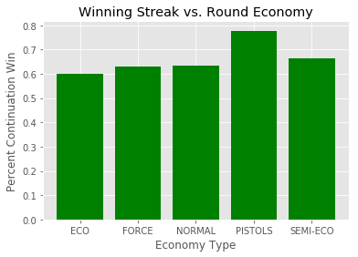

```python
plt.style.use('ggplot')

x_pos = [i for i, _ in enumerate(econ_labels)]

plt.bar(x_pos, mean_vals, color='green')
plt.xlabel("Economy Type")
plt.ylabel("Percent Continuation Win")
plt.title("Winning Streak vs. Round Economy")

plt.xticks(x_pos, econ_labels)

plt.show()
```

The repeat rate for ECO (saving) rounds is lower because the team that saved does not mind all that much that they lost the round and will have money to buy full gear and have a normal economy next round. Below I will isolate data from teams that won the round as an underdog to further look at the importance of winning a round that you commit your economy to.

### EFFECT OF AN UPSET VICTORY GIVEN ROUND ECONOMY TYPE

The above data is interesting but brings up an important question. If an underdog (the team with less equipment value) wins the round, does the economic type of the round have a larger impact on continued winning than it does on either team winning the next round (underdog or not).

We know that the values we just calculated and graphed above show the chance of a team winning the next round given they win the current one and splits this chance up by the economy of the round. So now we look at how the economy of the round effects an underdogs chance to win two rounds in a row. This is determining in a sense how 'important' an upset in different economies can be. For instance if winning a round when saving against a very geared team (Eco Round) will yeild a higher chance to win the next round than simply winning against an equally geared team (Normal Round).

```python
df_meta['poor_win'] = 0
#our new array of arrays for type and continuation win given an underdog winning
new_vals = []
#iterate metadata
for index, row in df_meta.iterrows():

    #if a side has cheaper equipment and wins
    if ((row.ct_eq_val < row.t_eq_val) and (row.winner_side == 'CounterTerrorist')) or \
       ((row.t_eq_val < row.ct_eq_val) and (row.winner_side == 'Terrorist')):
        #if that side also won the next round
        if row.next_rnd == 1:
            new_vals.append([row.round_type, 1])
        else:
            new_vals.append([row.round_type, 0])

#create the dataframe for this new data
headers = ['rnd', 'next']
df_poorer = pd.DataFrame(new_vals, columns = headers)
#output the grouped means which in this case again acts like percent values because of onehot encoding
df_poorer['next'].groupby(df_poorer['rnd']).mean()
```

```
rnd
ECO             0.618142
FORCE_BUY       0.575719
NORMAL          0.597589
PISTOL_ROUND    0.770587
SEMI_ECO        0.622492
Name: next, dtype: float64
```

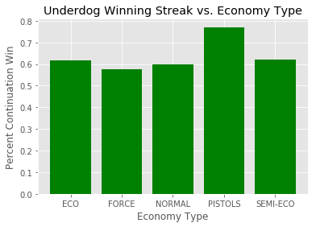

```python
win_rate_poor = df_poorer['next'].groupby(df_poorer['rnd']).mean().values
display_rates = df_poorer['next'].groupby(df_poorer['rnd']).mean()
plt.style.use('ggplot')

x_pos = [i for i, _ in enumerate(econ_labels)]

plt.bar(x_pos, win_rate_poor, color='green')
plt.xlabel("Economy Type")
plt.ylabel("Percent Continuation Win")
plt.title("Underdog Winning Streak vs. Economy Type")

plt.xticks(x_pos, econ_labels)

plt.show()
```

### HEATMAP OF PLAYSTYLE VS. ECONOMY TYPE

Here I dive into one more very interesting thing about economy type, how the current round economy actually effects the way skirmishes take place on the map. It is important to note to those who do not know much about CSGO that generally longer-range weapons are more expensive, at that weapons that can actually perform well at longrange are seen more in the hands of the richer team. Teams on ECO or SEMI-ECO rounds tend to have cheaper weapons like submachine guns and pistols, while richer teams will have mostly if not all assault and sniper rifles. Because of this I hypothesize that teams currently saving or semi-saving will play tighter and in chokes or closer to the bombsite. Looking to plant the bomb for a slim chance to win the round or to defend right ontop of the bomb for the same slim chance. To test this theory I will plot a heatmap of shots fired over two of the most popular maps for CSGO competitive play, Dust2 and Mirage.

The first thing that has be done in order to do this is to adjust the player coordinates in the damage data to fit the map they were recorded on. This is done using the mapdata we imported earlier that has the coordinate specs for the picture files of the maps that we downloaded. I did this in a vectorized way instead of line-by-line iteration through the damage data because at 5 million lines the kernel was hanging when iteration was used. Unlike the metadata which I iterated through this dataset was simply too big.

After this both the Dust2 and Mirage heatmaps will be plotted using Matplotlib framing and seaborn's kdeplot for the heatmap binning.

```python
#make coordinate adjustments for the damage data give the type of map the row was recorded on
#type of map listed in damage data because of the merge with metadata
maps_vec = maps_df.loc[full_df['map']]
maps_vec[['att_pos_x', 'att_pos_y', 'vic_pos_x', 'vic_pos_y']] = (full_df.set_index('map')[['att_pos_x', 'att_pos_y', 'vic_pos_x', 'vic_pos_y']])
maps_vec['att_pos_x'] = (maps_vec['ResX']*(maps_vec['att_pos_x']-maps_vec['StartX']))/(maps_vec['EndX']-maps_vec['StartX'])
maps_vec['att_pos_y'] = (maps_vec['ResY']*(maps_vec['att_pos_y']-maps_vec['StartY']))/(maps_vec['EndY']-maps_vec['StartY'])
maps_vec['vic_pos_x'] = (maps_vec['ResX']*(maps_vec['vic_pos_x']-maps_vec['StartX']))/(maps_vec['EndX']-maps_vec['StartX'])
maps_vec['vic_pos_y'] = (maps_vec['ResY']*(maps_vec['vic_pos_y']-maps_vec['StartY']))/(maps_vec['EndY']-maps_vec['StartY'])
#change the coordinate values in the damage data to the new coordinate values calculated
full_df[['att_pos_x', 'att_pos_y', 'vic_pos_x', 'vic_pos_y']] = maps_vec[['att_pos_x', 'att_pos_y', 'vic_pos_x', 'vic_pos_y']].values
```

```python
#sample 5% of the data for plotting using pandas build in random dataframe sampling
#while 10-20% could be used anything past that starts to be too much for simple heatmap binning
df_percent = full_df.sample(frac=0.05)
```

[figure not shown]

```python
#take the samples recorded on mirage map
mirage_df = df_percent.loc[df_percent.map == 'de_mirage']
#group by round type
econgrps = mirage_df.groupby(['round_type'])
#load in image of mirage map from files
miragemp = imread('de_mirage.png')
#create 6 subplots on fig (one for each econ group + 1 (has to be even))
fig, ((ax1, ax2, ax3),(ax4, ax5 ,ax6)) = plt.subplots(2,3,figsize=(20,20))
#array to hold subplot values and iterate them
axarr = [ax1, ax2, ax3, ax4, ax5, ax6]
#subplot counter
i = 0

for name, grp in econgrps:
    currax = axarr[i]
    currax.grid(b=True, which='major', color='w', linestyle='--', alpha=0.25)
    #plot map on mpl subfig and adjust to file dimensions
    currax.imshow(miragemp, zorder=0, extent=[0.0, 1024, 0., 1024])
    plt.xlim(0,1024)
    plt.ylim(0,1024)
    #do the heatmap binning for the current economy type
    sns.kdeplot(grp['att_pos_x'], grp['att_pos_y'], cmap='YlOrBr', bw=10, ax=currax)
    currax.set_title(name)
    i += 1

fig.delaxes(axarr[5])
```

To help understand the mechanics of this map here are articles on how to [attack](https://www.pcgamer.com/csgo-mirage-terrorist-guide/) and [defend](https://www.pcgamer.com/csgo-mirage-ct-guide/).

The above results are very interesting and in a lot of ways do back up what we hypothesized about the way economy effects playstyle. For the purpose of this analysis we can ignore the pistol round. Everyone has the same type of gun (pistol) and so people use preset strategies for these 2 rounds per match that work best for that specific situation of just pistols, this is why the pistol round heatmap looks so radically different than the other heatmaps.

Looking at the heatmaps for ECO and SEMI-ECO rounds we can see that they share the same darkest points as the FORCE BUY and NORMAL round heatmaps, but have significantly less action in some of the pockets of heat that FORCE BUY and NORMAL share in open spaces. I believe this is because the 'hottest' spots that all four of them share are chokepoints in the map that are extremely active no matter what the round type is, while the spots that are only in the FORCE and NORMAL rounds are indicative of heavy spending and ranged weapons. The ECO and SEMI-ECO heatmaps also overall have less hotspots than the other two, implying that during rounds where players on one team are saving that team is likely to stick to a few popular strategies and spots that they are comfortable playing with any (worse) weapons.

[figure not shown]

```python
#same as the above but for dust2
dust_df = df_percent.loc[df_percent.map == 'de_dust2']
econgrps_dust = dust_df.groupby(['round_type'])



dustmp = imread('de_dust2.png')
fig, ((ax1, ax2, ax3),(ax4, ax5 ,ax6)) = plt.subplots(2,3,figsize=(20,20))
axarr = [ax1, ax2, ax3, ax4, ax5, ax6]

i = 0

for name, grp in econgrps_dust:
    currax = axarr[i]
    currax.grid(b=True, which='major', color='w', linestyle='--', alpha=0.25)
    currax.imshow(dustmp, zorder=0, extent=[0.0, 1024, 0., 1024])
    plt.xlim(0,1024)
    plt.ylim(0,1024)
    sns.kdeplot(grp['att_pos_x'], grp['att_pos_y'], cmap='YlOrBr', bw=10, ax=currax)
    currax.set_title(name)
    i += 1

fig.delaxes(axarr[5])
```

To help understand the mechanics of this map here are articles on how to [attack](https://www.pcgamer.com/csgo-dust2-terrorist-guide/) and [defend](https://www.pcgamer.com/csgo-dust2-ct-guide/).

Dust2 is a good second set of results to analyze after Mirage because the map is longer and simpler. With corridors and sneaky paths to objectives there are therefore less chokepoints, and the map has a heavy emphasis on long, ranged battle. This shows in the heatmaps. The heatmaps for NORMAL and FORCEBUY rounds show many dark (high heat) spots all along the map, most of these behind various formed of cover like doors or walls before a long corridor. These long corridors like the one on the very right of the map having deep red on both ends during FORCE and especially NORMAL rounds, indicating that because the economy is good for both teams they are firing at eachother from long range looking for a kill to move forward on. During ECO and SEMI-ECO rounds you can see that the longer corridors only have darker sections one end, indicating that they have either made it to a doorway and both teams are firing close to eachother, or that the richer team is killing the poorer one firing heavy from far away, taking little fire back.

ECO and SEMI-ECO teams rounds also show more heat in the 'tunnels' section of the map. Which is the section off to the left from the center. This is the one close-quarters section of an otherwise relatively longrange map and indicates that teams with cheaper submachine guns have chosen to take that route for short-range engagements.

### CONCLUSION

In conclusion, we found that the current economy in any given round has a large effect on not only the importance of winning or losing the round, but also on the way the round is actually played on any given map. This validates the CSGO communities' long-held beliefs that the most important skill for a team as a whole is playing around the game's economy. This is something that a lot of amatuers do not think about and words like 'SEMI-ECI' and 'FORCE BUY' are usually reserved for the professional scene. But after exploration this ESEA server data I am comfortable saying that the economy is a very important feature of the game that any aspiring player or coach should become extremely familiar with.

In this tutorial I also worked with the largest data (5mil x 30) that I have ever worked with, and while I was able to use iteration for all of the basic projects in CMSC320, working with data this taught me about the importance of vectorization, relational databases, and properly sampling when the data is too much for a specific purpose.

For further research I think it would be interesting to look at the effect of the current game economy and what happened during past just the next round and deeper into the match. It would also be interesting to look at the effects of different kill rewards for different guns on the economy, and the ROIs of certain guns and how useful that ROI actually was given the economic state of the match. This could be valuable information for coaches and pro teams, especially in tournaments where millions of dollars are on the line.

Lastly for anyone interested in Pro CSGO I recommend looking [here](https://pro.eslgaming.com/csgo/proleague/) and [here](https://www.reddit.com/r/GlobalOffensive/).